# Bridges and Unemployment

Qianyu Liu  
February 22, 2018

### Assignment

Fit a simple linear model where *y*<sub>*i*</sub> is the unemployment rate for county *i* and *x*<sub>*i*</sub> is something about county *i* from the bridges data (e.g. the value plotted on the map in 1 above). Then, make a map of *y*<sub>*i*</sub>, another map of *x*<sub>*i*</sub>, and a final map of the residuals from the linear regression.

You can directly edit this document, making sure to "properly" cite things that are not yours (e.g. add a comment that this is from xyz).

Below, I have put some code to get you started. It is the code that we have been using in the past classes.

### Some code to get started.

```r
library(choroplethr)
library(choroplethrMaps)
library(data.table)
library(tidyverse)
```

From the downloaded data `dat`, we select some columns, zoom-in to Wisconsin, and create a rating for the bridges.

```r
keep = c("STATE_CODE_001", "STRUCTURE_NUMBER_008" , "COUNTY_CODE_003", "LAT_016", "LONG_017", "TOLL_020" , "ADT_029"           ,      "YEAR_ADT_030" ,
         "YEAR_BUILT_027" , "DECK_COND_058" , "SUPERSTRUCTURE_COND_059", "SUBSTRUCTURE_COND_060"  , "CHANNEL_COND_061","CULVERT_COND_062", "DATE_OF_INSPECT_090"   ,  "FRACTURE_092A",  "UNDWATER_LOOK_SEE_092B" , "SPEC_INSPECT_092C"  )

x = select(dat, one_of(keep))

wi = filter(x, STATE_CODE_001 == 55)


# make function to rate bridge as NA, good, bad, fail, using
# colnames(wi)[10:13]
# "SUPERSTRUCTURE_COND_059" "SUBSTRUCTURE_COND_060"   "CHANNEL_COND_061"        "CULVERT_COND_062"
# good = 5:9
# bad = 2:4
# fail = 0:1

# cond "condition" is the minimum of the given ratings.
wi = mutate(wi, cond = pmin(SUPERSTRUCTURE_COND_059, SUBSTRUCTURE_COND_060, CHANNEL_COND_061,CULVERT_COND_062,
                            na.rm = T))

rateIt = function(cond){
  # gives a good to fail rating for cond.
  rate = rep("good", length(cond))
  rate[cond<5] = "bad"
  rate[cond <2]= "fail"
  return(rate)
}

wi$rate = rateIt(wi$cond)
table(wi$cond)
```

```
##
##    0    1    2    3    4    5    6    7    8    9
##    8    8   16  188  807 2260 3850 4862 2042  212
```

```r
table(wi$rate)
```

```
##
##   bad  fail  good
##  1011    16 13226
```

Next, we make a map of bridge quality, by Wisconsin county.

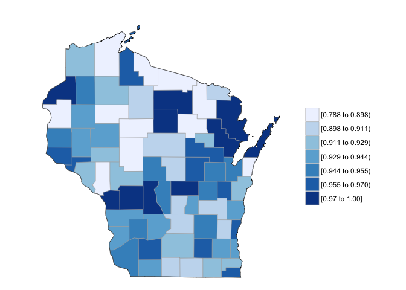

```r
wi = filter(wi, cond>1)
# ggplot(data = wi, mapping = aes(y = log(ADT_029), x =YEAR_BUILT_027, col = rate)) +geom_point() + geom_smooth()
wi = wi %>% mutate(fips = STATE_CODE_001*1000+COUNTY_CODE_003)
wi = wi %>% mutate(good = (rate == "good"))
fipsdat = wi %>% group_by(fips) %>% summarize(propGoodRoads = mean(good))
fipsdat %>% transmute(region = fips, value = propGoodRoads) %>% county_choropleth(state_zoom = "wisconsin")
```

Now, let's download the BLS unemployment data. For some reason, `download.file` is not running in the markdown document. So, run these lines in your working directory before re-compiling this code.

```r
library(blscrapeR)
library(dplyr)
library(choroplethr)
## blscraeR does a lot of clean up of this file:  https://www.bls.gov/web/metro/laucntycur14.txt
x = get_bls_county() %>% as.tbl
save(x, file = "unemployment.RData")
```

Now, make a map with some pipes!

```r
# pipe it!
load("unemployment.RData")  # if this gives an error, make sure you (1) downloaded the data (see last chunk) and (2) saved it in the current working directory.
x %>%
  mutate(value = as.numeric(unemployed_rate), region = as.numeric(fips)) %>%
  select(region, value) %>%
  county_choropleth
```

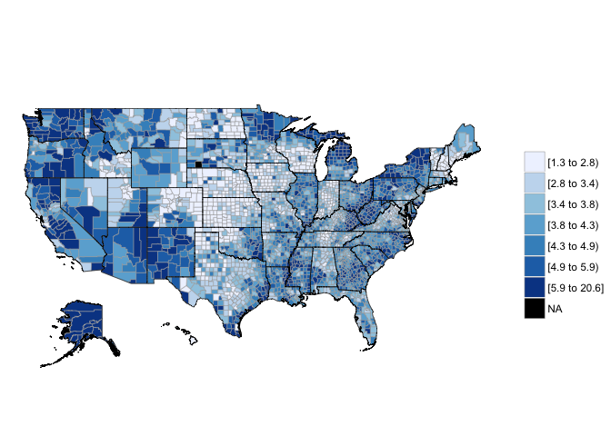

```r
keep = c("STATE_CODE_001", "STRUCTURE_NUMBER_008" , "COUNTY_CODE_003", "LAT_016", "LONG_017", "TOLL_020" , "ADT_029"           ,      "YEAR_ADT_030" ,
         "YEAR_BUILT_027" , "DECK_COND_058" , "SUPERSTRUCTURE_COND_059", "SUBSTRUCTURE_COND_060"  , "CHANNEL_COND_061","CULVERT_COND_062", "DATE_OF_INSPECT_090"   ,  "FRACTURE_092A",  "UNDWATER_LOOK_SEE_092B" , "SPEC_INSPECT_092C"  )

y = select(dat, one_of(keep))

y = mutate(y, cond = pmin(SUPERSTRUCTURE_COND_059, SUBSTRUCTURE_COND_060, CHANNEL_COND_061,CULVERT_COND_062,
                            na.rm = T))

rateIt = function(cond){
  # gives a good to fail rating for cond.
  rate = rep("good", length(cond))
  rate[cond<5] = "bad"
  rate[cond <2]= "fail"
  return(rate)
}

y$rate = rateIt(y$cond)
table(y$cond)
```

```
##
##      0      1      2      3      4      5      6      7      8      9
##   1044    459   1865   8866  38318 118055 198275 186317  55444   6315
##      N
##     44
```

```r
table(y$rate)
```

```
##
##    bad   fail   good
##  49049   1503 564450
```

```r
y = filter(y, cond>1)
# ggplot(data = wi, mapping = aes(y = log(ADT_029), x =YEAR_BUILT_027, col = rate)) +geom_point() + geom_smooth()
y = y %>% mutate(fips = STATE_CODE_001*1000+COUNTY_CODE_003)
y = y %>% mutate(good = (rate == "good"))
fipsdat = y %>% group_by(fips) %>% summarize(propGoodRoads = mean(good))
```

```r
x$fips <- as.numeric(x$fips)
index=which(is.na(fipsdat$fips))
fipsdat=fipsdat[-index,]
x$propGoodRoads=NA
for (i in 1:nrow(x)){
  for (j in 1:nrow(fipsdat)){
    if(x$fips[i]==fipsdat$fips[j]){
      x$propGoodRoads[i]=fipsdat$propGoodRoads[j]
      break
    }
  }
}

index=which(is.na(x$propGoodRoads))
newdata=x[-index,]
```

## map of proportion of good-condition roads

```r
newdata %>% transmute(region = fips, value = propGoodRoads) %>%
  select(region, value) %>%
  county_choropleth
```

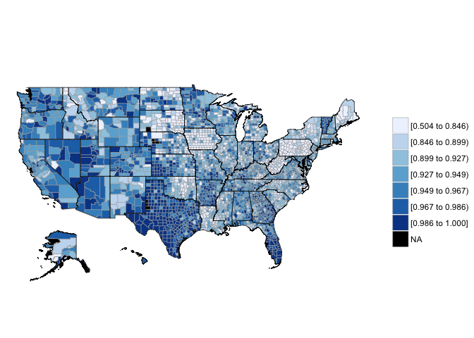

# map of the residuals

```r
m <- lm(unemployed_rate~propGoodRoads, data = newdata)
newdata %>%
  transmute(region = newdata$fips, value = m$residuals) %>%
  select(region, value) %>%
  county_choropleth
```

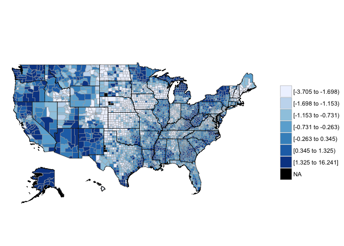